# Computing lab: Stan Basics

North-South-AIMS-Imperial: modern statistics and global health

Yu Chen and Oliver Ratmann

# 1 Study objectives

Hello all!

By the end of this lab,

- you will understand the key benefits of modern statistical computing languages such as `Stan`; and
- you will have installed the `Stan` software within `R`, either via `rstan` or `cmdstanr`; and
- you will be familiar with a typical analysis workflow using `Stan`, and associated `R` commands.

# 2 Why Stan?

There are several modern alternatives to `Stan`, including

- [numpyro](https://num.pyro.ai/en/latest/index.html#introductory-tutorials); and
- [TMD](https://github.com/kaskr/adcomp/wiki); and
- [Nimble](https://r-nimble.org).

# 3 Installation

The first objective of today’s lab is to install `Stan` on your computer, along with related helpful packages. Please consult the installation instructions below in detail. A key step in working with `Stan` is that your model is compiled using `C++`, and for this step `R` needs to know where your compilers live, and the correct compiler versions of course also need to be installed. This is why you need to install and configure the chain of `C++` tools on your Linux, MacOS, or Windows system as described below, and this is why installation is a little more involved compared to installations of most other `R` packages.

Install `rstan`:

- https://github.com/stan-dev/rstan/wiki/RStan-Getting-Started
- Tip: It is strongly recommend to install `rstan` in `R` version 4.0.0 or higher;
- For MacOS, [compared to previous approaches, I find the instructions through the macrtools package](https://mac.thecoatlessprofessor.com/macrtools/) most helpful;
- If the above results in timeouts, install the missing software manually [as described here](https://mac.r-project.org/tools/);
- Verify your installation as described on the `RStan-Getting-Started` website.

Alternatively install `cmdstanr`:

- [https://mc-stan.org/cmdstanr/](https://mc-stan.org/cmdstanr/articles/cmdstanr.html)
- `cmdstanr` is a recently developed lightweight alternative to `rstan`. The functions to compile, run, and access the output of Bayesian inference algorithms are very similar, but not identical to those in the `rstan` package. However, both `cmdstanr` and `stanr` read exactly the same `Stan` model files, and so `cmdstanr` is an excellent alternative if you run into installation issues with `rstan`, or if you would rather work with the most recent `R` interface to `Stan`’s algorithms;
- Verify your installation as described on the `Cmdstanr-Getting-Started` website.

Then install `bayesplot` using `install.packages("bayesplot")` in `R`.

# 4 Hello world example, using rstan

Let us start with a very simple example to become familiar with `Stan`.

We aim to fit a normal model to 100 data points $y_i, i=1,\dotsc,n=100$, and estimate the joint posterior distribution of the mean and standard deviation numerically with Stan,

$$\begin{align*}
&y_{i} \sim \text{Normal}(\mu, \sigma^2) \\
& \mu \sim \text{Normal}(0,100)\\
& \sigma\sim \text{Half-Cauchy}(0,1).
\end{align*}$$

Let us compile the corresponding `Stan` model and run two Hamiltonian Monte Carlo (HMC) chains for 4,000 iterations each, including 1,000 warmup iterations.

Every `Stan` model files is structured in terms of the following blocks:

- `data` block: specifies data required to fit the model
- `transformed data` block: specifies temporary transformations of the data, e.g. QR decomposition of $X$; variables that do not change
- `parameters` block: specifies all parameters that are fitted; cannot be assigned values directly
- `transformed parameters` block: optional transformations of parameters, e.g. risk differences
- `model` block: specifies the model in terms of likelihood and priors
- `generated quantities` block: quantities that depend on parameters and data, and do not affect inference

Here is a simple implementation of our Hello World normal model:

```r
# Hello World normal model
model1_text <- "
data{
    int<lower=1> N;
    real y[N];
}
parameters{
    real mu;
    real<lower=0> sigma;
}
model{
    sigma ~ cauchy( 0 , 1 );
    mu ~ normal( 0 , 10 );
    y ~ normal( mu , sigma );
}
"
```

To use this model in `R`, we start by loading up our `R` packages:

```r
require(data.table) # data mangling
require(ggplot2) # for plotting
require(hexbin) # for plotting
require(tidyverse) # data mangling
require(rstan) # run Stan from R
require(bayesplot) # plot Stan output
require(knitr) # for Rmarkdown
require(kableExtra) # for Rmarkdown

# change this line as needed to point to the directory
#    where all output from this lab is stored
out.dir <- '/Users/yu/Library/CloudStorage/OneDrive-ImperialCollegeLondon/conference/AIMS_workshop_Rwanda_2024/AIMS-Imperial-workshop/src/stan_intro_lab'

# set options relevant to rstan
options(mc.cores = 1)
rstan:::rstan_options(auto_write = TRUE)
```

Now, please complete the following code block to sample from the joint posterior associated with the Hello World model for 4,000 iterations including 1,000 iterations of warmup. Setup two Hamiltonian Monte Carlo chains and initialise the two chains at $(\mu=1, \sigma=2)$ and $(\mu=-1, \sigma=0.5)$:

```r
# compile Stan model
#   Make data
set.seed(010680)    # use your birth date
y <- rnorm(1e2, mean = 0, sd = 1)
stan_data <- list()
stan_data$N <- length(y)
stan_data$y <- y

model1_compiled <- rstan::stan_model(
  model_name = 'model1',
  model_code = gsub('\t',' ',model1_text)
  )
```

```
#> Trying to compile a simple C file
```

```r
# run Stan
model1_fit <- rstan::sampling(model1_compiled,
  data = stan_data,
  warmup = 1e3,
    iter = 4e3,
    chains = 2,
    init = list( list(mu = 1,sigma = 2),list(mu = -1, sigma = 0.5) )
  )

# save output to RDS
saveRDS(model1_fit, file = file.path(out.dir, "model1_fit_rstan.rds"))
```

Next, we explore the following code snippets that provide key functions to assess the Monte Carlo output.

```r
# load output from RDS
model1_fit <- readRDS(file = file.path(out.dir, "model1_fit_rstan.rds"))
model1_pars <- c("mu", "sigma")

# assess mixing and convergence
print(model1_fit,
      pars = model1_pars,
      probs = c(0.025, 0.25, 0.5, 0.75, 0.975),
      digits_summary = 2)
```

[output not shown]

```r
print(model1_fit, digits = 2)
```

[output not shown]

```r
# to plot traces and assess convergence,
# extract Monte Carlo samples including warmup and without permutation
#
# often helpful to plot the log posterior density too
model1_po <- rstan:::extract(model1_fit,
                             pars = c("lp__",model1_pars),
                             inc_warmup = TRUE,
                             permuted = FALSE)

# make trace plots
bayesplot:::color_scheme_set("mix-blue-pink")
p <- bayesplot:::mcmc_trace(model1_po,
                            pars = c("lp__",model1_pars),
                            n_warmup = 1e3,
                            facet_args = list(nrow = 2))

pdf(file = file.path(out.dir,'model1_trace.pdf'), width = 10, height = 8)
print(p)
dev.off()
```

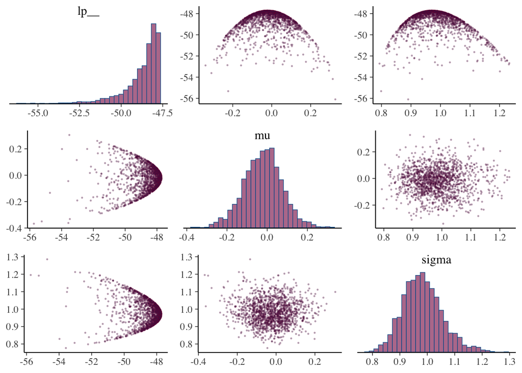

```r
# make pairs plots of samples excluding warmup
#
# often helpful to plot the log posterior density too
model1_po <- rstan:::extract(model1_fit,
                             pars = c("lp__",model1_pars),
                             inc_warmup = FALSE,
                             permuted = FALSE)

p <- bayesplot::mcmc_pairs(model1_po,
                           pars = c("lp__",model1_pars),
                           off_diag_args = list(size = 0.3, alpha = 0.3))
print(p)
```

```r
dev.off()
```

```r
ggsave(file = file.path(out.dir,'model1_pairsplot.png'),
       plot = p,
       h = 20,
       w = 20,
       limitsize = FALSE)
```

```r
# to manipulate the posterior Monte Carlo samples after warmup
# we typically prefer to
# extract Monte Carlo samples as a data frame
#
# we will review the melt and dcast functions later as well
# but do note their use here
model1_pars <- c("mu", "sigma")
model1_po <- rstan:::extract(model1_fit,
                             pars = model1_pars,
                             inc_warmup = FALSE,
                             permuted = FALSE)
model1_po <- as.data.frame(model1_po)
# there is much left to desire with output in this form,
# we mangle this as follows
model1_po <- as.data.table(model1_po)
model1_po[, iteration := seq_len(nrow(model1_po))]
model1_po <- data.table::melt(model1_po, id.vars = 'iteration')
model1_po[, chain := gsub('(.*)\\.(.*)','\\1',variable)]
model1_po[, chain := as.integer(stringr::str_replace(chain, "chain:", ""))]
model1_po[, variable := gsub('(.*)\\.(.*)','\\2', variable)]

model1_po <- data.table::dcast(model1_po,
                               iteration + chain ~ variable,
                               value.var = 'value')
model1_po
```

[output not shown]

# 5 The flat priors example

Let us adapt the Hello World example a wee bit, so that we can explore how a non-successful numerical inference run with `Stan` might look like.

We will engineer a statistical problem that is very hard to sample from, due to unsuitable prior specifications. First, we will reduce the data to just two data points. Second, we will specify unbounded uniform priors are specified for both $\mu$ and $\sigma$, which says that prior values close to infinity are as likely as close to zero.

The learning outcome here is that a common reason why `Stan` fails to sample from a joint posterior is that the priors are mis-specified as either way too wide, or way too narrow.

```r
# data now consist of TWO data points ONLY
y <- c(-1,1)
stan_data <- list()
stan_data$N <- length(y)
stan_data$y <- y

# specify Stan model with flat prior on mu and sigma
model2_text <- "
data{
    int<lower=1> N;
    real y[N];
}
parameters{
    real mu;
    real<lower=0> sigma;
}
model{
    y ~ normal( mu , sigma );
}
"
```

```r
model2_compiled <- rstan::stan_model(
  model_name = 'model2',
  model_code = gsub('\t',' ',model2_text)
  )

# run Stan
model2_fit <- rstan::sampling(model2_compiled,
  data = stan_data,
  warmup = 1e3, iter = 4e3, chains = 2,
  init = list( list(mu = 0,sigma = 1),list(mu = 0,sigma = 1) )
  )
```

```r
# trace plots
po <- rstan:::extract(model2_fit, inc_warmup = TRUE, permuted = FALSE)
bayesplot:::color_scheme_set("mix-blue-pink")
p <- bayesplot:::mcmc_trace(po,  pars = c("mu", "sigma"), n_warmup = 1e3,
        facet_args = list(nrow = 2, labeller = label_parsed))
pdf(file = file.path(out.dir,'model2_trace_flat_prior_N2.pdf'), width = 10, height = 6)
print(p)
dev.off()
```

For comparison, let us now place weakly informative priors on $\mu$ and $\sigma$, and repeat the excercise:

```r
# data now TWO data points ONLY
y <- c(-1,1)
stan_data <- list()
stan_data$N <- length(y)
stan_data$y <- y

# specify Stan model with weakly informative prior on mu and sigma
model3_text <- "
data{
    int<lower=1> N;
    real y[N];
}
parameters{
    real mu;
    real<lower=0> sigma;
}
model{
    sigma ~ cauchy( 0 , 1 );
    mu ~ normal( 0 , 10 );
    y ~ normal( mu , sigma );
}
"
```

```r
# compile model
model3_compiled <- rstan::stan_model(
  model_name = 'model3',
  model_code = gsub('\t',' ',model3_text)
  )

# run Stan
model3_fit <- rstan::sampling(model3_compiled,
  data = stan_data,
  warmup = 1e3, iter = 4e3, chains = 2,
  init = list( list(mu = 0,sigma = 1),list(mu = 0,sigma = 1) )
  )

# trace plots
po <- rstan:::extract(model3_fit, inc_warmup = TRUE, permuted = FALSE)
bayesplot:::color_scheme_set("mix-blue-pink")
p <- bayesplot:::mcmc_trace(po,  pars = c("mu", "sigma"), n_warmup = 1e3,
        facet_args = list(nrow = 2, labeller = label_parsed))
pdf(file = file.path(out.dir,'model3_trace_winformative_prior_N2.pdf'), width = 10, height = 6)
print(p)
dev.off()
```

What do you observe in terms of convergence, mixing, and the HMC traces in general?

# 6 The unidentifiable parameters example

Finally, we will adapt the Hello World example slightly differently, again to explore how a non-successful numerical inference run with `Stan` might look like in the case when two parameters cannot be estimated from the data, only their combination. To engineer this situation, we will introduce two unknown random variables $\alpha_1$ and $\alpha_2$, and say that the sum of both is the mean in our Hello World normal model.

The learning outcome here is that a common reason why `Stan` fails to sample from a joint posterior is that the parameters in a model are highly correlated, and there are multiple equally likely solutions under the model as specified.

Let us start with unbounded uniform priors specified on $\alpha_1$ and $\alpha_2$.

```r
# data now TWO data points ONLY
y <- c(-1,1)
stan_data <- list()
stan_data$N <- length(y)
stan_data$y <- y

# specify Stan model with unidentifiable parameters and flat prior
model4_text <- "
data{
    int<lower=1> N;
    real y[N];
}
parameters{
    real alpha1;
    real alpha2;
    real<lower=0> sigma;
}
transformed parameters{
    real mu= alpha1 + alpha2;
}
model{
    sigma ~ cauchy( 0 , 1 );
    y ~ normal( mu , sigma );
}
"
```

```r
model4_compiled <- rstan::stan_model(
  model_name = 'model4',
  model_code = gsub('\t',' ',model4_text)
  )

# run Stan
model4_fit <- rstan::sampling(model4_compiled,
  data = stan_data,
  warmup = 1e3, iter = 4e3, chains = 2,
  init = list( list(alpha1 = 0,alpha2 = 0,sigma = 1),list(alpha1 = 0,alpha2 = 0,sigma = 1) )
  )
```

```r
# trace plots
po <- rstan:::extract(model4_fit, inc_warmup = TRUE, permuted = FALSE)
bayesplot:::color_scheme_set("mix-blue-pink")
p <- bayesplot:::mcmc_trace(po,  pars = c("mu", "sigma"), n_warmup = 1e3,
        facet_args = list(nrow = 2, labeller = label_parsed))
pdf(file = file.path(out.dir,'model4_trace_unidentifiable_flat_prior_N2.pdf'), width = 10, height = 6)
print(p)
dev.off()
```

```r
# data now consist of TWO data points ONLY
y <- c(-1,1)
stan_data <- list()
stan_data$N <- length(y)
stan_data$y <- y

# specify Stan model with unidentifiable parameters and weakly informative prior
model5_text <- "
data{
    int<lower=1> N;
    real y[N];
}
parameters{
    real alpha1;
    real alpha2;
    real<lower=0> sigma;
}
transformed parameters{
    real mu= alpha1 + alpha2;
}
model{
    sigma ~ cauchy( 0 , 1 );
    alpha1 ~ normal(0, 10);
    alpha2 ~ normal(0, 10);
    y ~ normal( mu , sigma );
}
"
```

```r
# data now consist of TWO data points ONLY
model5_compiled <- rstan::stan_model(
  model_name = 'model5',
  model_code = gsub('\t',' ',model5_text)
  )

# run Stan
model5_fit <- rstan::sampling(model5_compiled,
  data = stan_data,
  warmup = 1e3, iter = 4e3, chains = 2,
  init = list( list(alpha1 = 0,alpha2 = 0,sigma = 1),list(alpha1 = 0,alpha2 = 0,sigma = 1) )
  )
```

```r
# trace plots
po <- rstan:::extract(model5_fit, inc_warmup = TRUE, permuted = FALSE)
bayesplot:::color_scheme_set("mix-blue-pink")
p <- bayesplot:::mcmc_trace(po,  pars = c("mu", "sigma"), n_warmup = 1e3,
        facet_args = list(nrow = 2, labeller = label_parsed))
pdf(file = file.path(out.dir,'model5_trace_unidentifiable_winformative_prior_N2.pdf'), width = 10, height = 6)
print(p)
dev.off()
```

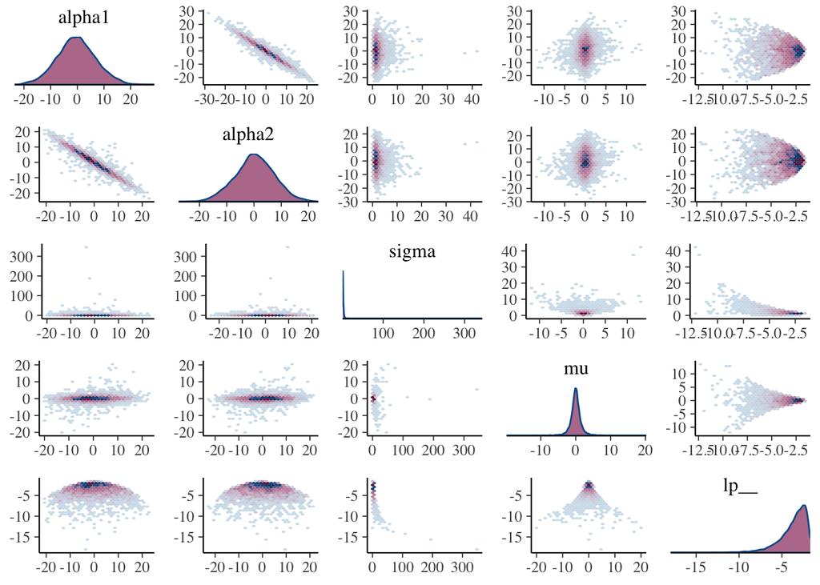

```r
# pair plot
p <- bayesplot::mcmc_pairs(po, diag_fun = "dens", off_diag_fun = "hex")
ggsave(file = file.path(out.dir,'model5_pair_unidentifiable_winformative_prior_N2.pdf'), p, w = 10, h = 10)
print(p)
```

```r
dev.off()
```

Let us reflect on the trace plots and the pair plots for the different models:

- What do you observe in terms of convergence, mixing, and the HMC traces in general?
- What does the pair plot reveal to you?

```r
# The first observation is that provided that the prior distributions on model parameters are
# suitably specified through e.g. weakly informative priors, then Stan's Hamiltonian Monte Carlo
# algorithm usually works very well to provide us with Monte Carlo samples from the joint posterior
# distribution.
#
# The second observation is related to the pairs plot. We can see that several parameters are
# extremely highly correlated. In fact, the posterior alpha1 is essentially equal to -alpha2.
# This means that the joint posterior distribution is essentially concentrated on a hyperplane, a set
# of measure zero. Yet, Stan's algorithm understands the geometry of the posterior distribution,
# and can efficiently sample from it. This would be very difficult with a standard Metropolis
# Hastings algorithm.
```

# 7 Hello world example, using cmdstanr

Finally, we revisit our Hello World example to see how exactly each step above can be implemented with `cmdstanr`:

```r
require(data.table) # data mangling
require(tidyverse) # data mangling
require(bayesplot) # plot Stan output
require(knitr) # for Rmarkdown
require(kableExtra) # for Rmarkdown
require(cmdstanr) # for Stan

# change this line as needed to point to the directory
#    where all output from this lab is stored
out.dir <- '/Users/yu/Library/CloudStorage/OneDrive-ImperialCollegeLondon/conference/AIMS_workshop_Rwanda_2024/AIMS-Imperial-workshop/src/stan_intro_lab'

model1_cmdstan_text <- "
data{
    int<lower=1> N;
    array [N] real y; //using latest Stan syntax
}
parameters{
    real mu;
    real<lower=0> sigma;
}
model{
    sigma ~ cauchy( 0 , 1 );
    mu ~ normal( 0 , 10 );
    y ~ normal( mu , sigma );
}
"

#   Make data
set.seed(010680)    # use your birth date
y <- rnorm(1e2, mean = 0, sd = 1)
stan_data <- list()
stan_data$N <- length(y)
stan_data$y <- y

# cmdstanr requires the model to be written to a file
model1_filename <- cmdstanr::write_stan_file(
  gsub('\t',' ',model1_cmdstan_text),
  dir = out.dir,
  basename = NULL,
  force_overwrite = FALSE,
  hash_salt = ""
)

# compile Stan model
model1_compiled_cmdstanr <- cmdstanr::cmdstan_model(model1_filename)

# sample from joint posterior of the Hello World model with cmdstanr
model1_fit_cmdstanr <- model1_compiled_cmdstanr$sample(
  data = stan_data,
  seed = 123,
  chains = 2,
  parallel_chains = 2,
  refresh = 500, # print update every 500 iters,
  save_warmup = TRUE,
  init = list( list(mu = 1,sigma = 2),list(mu = -1, sigma = 0.5) )
)
```

```
#> Running MCMC with 2 parallel chains...
#>
#> Chain 1 Iteration:    1 / 2000 [  0%]  (Warmup)
#> Chain 1 Iteration:  500 / 2000 [ 25%]  (Warmup)
#> Chain 1 Iteration: 1000 / 2000 [ 50%]  (Warmup)
#> Chain 1 Iteration: 1001 / 2000 [ 50%]  (Sampling)
#> Chain 1 Iteration: 1500 / 2000 [ 75%]  (Sampling)
#> Chain 1 Iteration: 2000 / 2000 [100%]  (Sampling)
#> Chain 2 Iteration:    1 / 2000 [  0%]  (Warmup)
#> Chain 2 Iteration:  500 / 2000 [ 25%]  (Warmup)
#> Chain 2 Iteration: 1000 / 2000 [ 50%]  (Warmup)
#> Chain 2 Iteration: 1001 / 2000 [ 50%]  (Sampling)
#> Chain 2 Iteration: 1500 / 2000 [ 75%]  (Sampling)
#> Chain 2 Iteration: 2000 / 2000 [100%]  (Sampling)
#> Chain 1 finished in 0.1 seconds.
#> Chain 2 finished in 0.1 seconds.
#>
#> Both chains finished successfully.
#> Mean chain execution time: 0.1 seconds.
#> Total execution time: 0.8 seconds.
```

```r
# save output to RDS
model1_fit_cmdstanr$save_object(file = file.path(out.dir, "model1_compiled_cmdstanr.rds"))
```

```r
# load output from RDS
model1_fit_cmdstanr <- readRDS(file.path(out.dir, "model1_compiled_cmdstanr.rds"))

model1_pars <- c("mu", "sigma")

# assess mixing and convergence
model1_fit_cmdstanr$summary(
  variables = model1_pars,
  posterior::default_summary_measures(),
  extra_quantiles = ~posterior::quantile2(., probs = c(.0275, .975))
)
```

```
#> # A tibble: 2 × 9
#>   variable    mean  median     sd    mad     q5   q95  q2.75 q97.5
#>   <chr>      <num>   <num>  <num>  <num>  <num> <num>  <num> <num>
#> 1 mu       -0.0159 -0.0166 0.101  0.0980 -0.178 0.152 -0.213 0.190
#> 2 sigma     0.986   0.978  0.0741 0.0703  0.875 1.12   0.860 1.15
```

```r
# to plot traces and assess convergence,
# extract Monte Carlo samples including warmup in default array format
# that keeps all chains separate
#
# often helpful to plot the log posterior density too
model1_po <- model1_fit_cmdstanr$draws(
  variables = c("lp__",model1_pars),
  inc_warmup = TRUE,
  format = "draws_array"
  )

# make trace plot
p <- bayesplot:::mcmc_trace(model1_po,
                            pars = c("lp__",model1_pars),
                            n_warmup = 1e3,
                            facet_args = list(nrow = 2)
                            )
pdf(file = file.path(out.dir,'model1_cmdstanr_trace.pdf'), width = 10, height = 8)
print(p)
dev.off()
```

```r
# make pairs plots of samples excluding warmup
#
# often helpful to plot the log posterior density too
model1_po <- model1_fit_cmdstanr$draws(
  variables = c("lp__",model1_pars),
  inc_warmup = FALSE,
  format = "draws_array"
  )
p <- bayesplot::mcmc_pairs(model1_po,
                           pars = c("lp__",model1_pars),
                           off_diag_args = list(size = 0.3, alpha = 0.3)
                           )
ggsave(file = file.path(out.dir,'model1_cmdstanr_pairsplot.png'),
       plot = p,
       h = 20,
       w = 20,
       limitsize = FALSE
       )
# to manipulate the posterior Monte Carlo samples after warmup
# we typically prefer to
# extract Monte Carlo samples as a data frame
model1_pars <- c("mu", "sigma")
model1_po <- model1_fit_cmdstanr$draws(
  variables = model1_pars,
  inc_warmup = FALSE,
  format = "draws_df"
  )
model1_po <- as.data.table(model1_po)
setnames(model1_po, names(model1_po), gsub("\\.","",names(model1_po)))
```